# ch01_01_ML_start_v13_2601

## ch01 머신러닝 시작하기

- Machine Learning with sklearn @ DJ,Lim
- update : 2026/01

### 학습 내용

- 머신러닝을 학습하기 위한 기본 라이브러리 이해 및 실습
- 머신러닝 모델 만들어보기

### 01 기본 개념 이해하기

- **샘플(sample) or 데이터 포인터(data point)** : 하나의 개체 또는 관측치로, 데이터셋의 행(row)에 해당
- 특성 or 속성(feature) : 샘플의 개별 속성으로, 데이터셋의 열(column)에 해당.

### 02 기본 라이브러리 이해하기

### scikit-learn(사이킷 런)

- 오픈 소스입니다.
- 매우 인기 높고 독보적인 파이썬 머신러닝 라이브러리입니다.
- url : http://scikit-learn.org/stable/documentation
- 사용자 가이드 : https://scikit-learn.org/stable/user_guide.html

### Numpy

- 파이썬으로 과학 계산을 하기 위한 꼭 필요한 패키지
- 다차원 배열을 위한 기능
- 선형 대수 연산 기능
- 푸리에 변환 같은 고수준 수학 함수와 유사 난수 생성기 기능
- python의 데이터 처리에 비해 매우 빠른 속도를 보여주어 pandas, 딥러닝 모델의 기본 자료형으로 사용
- JAX, CuPy 등과의 호환성을 통해 GPU 가속 지원 확대
- url : https://www.numpy.org/

### Pandas

- 데이터 처리와 분석을 위한 파이썬 라이브러리
- url : https://pandas.pydata.org/
- R의 data.frame을 본떠 설계한 **Dataframe**이라는 데이터 구조를 기반으로 만들어짐.
- SQL 처럼 테이블 쿼리나 조인을 수행 가능함.
- xlsx, csv등의 다양한 파일과 데이터베이스에서 데이터를 읽어들 일 수 있음.
- https://pandas.pydata.org/pandas-docs/stable/getting_started/10min.html

### PyTorch & TensorFlow

- 심층학습(딥러닝)을 위한 두 주요 프레임워크
- PyTorch가 연구 분야에서 주도권을 가지며 산업계에서도 빠르게 성장 중
- TensorFlow/Keras는 프로덕션 환경에서의 강점 유지
- URL: https://pytorch.org/ 및 https://www.tensorflow.org/

### Matplotlib

- 파이썬 대표적인 과학 계산용 그래프 라이브러리

### Hugging Face

- 트랜스포머 기반 모델과 대규모 언어 모델(LLM)을 위한 생태계
- 사전 훈련된 수천 개의 모델과 데이터셋 제공
- URL: https://huggingface.co/

### SciPy

- SciPy(https://www.scipy.org/scipylib) 과학 계산용 함수를 모아놓은 파이썬 패키지.
- 고성능 선형대수 기능, 함수 최적화, 신호 처리, 특수한 수학 함수와 통계 분포 등
- 희소 행렬 기능

### mglearn

- 파이썬 라이브러리를 활용한 머신러닝 저자가 작성한 라이브러리
- 기본 머신러닝 내용 설명을 위한 그래프(knn 알고리즘 설명 등)

### 새로운 흐름

- 벡터 데이터베이스(Pinecone, Milvus): 임베딩 저장 및 검색
- LangChain & LlamaIndex: LLM 애플리케이션 개발을 위한 프레임워크
- 가속 컴퓨팅(RAPIDS, JAX): GPU 활용 데이터 처리 및 모델 훈련

### 현대적 머신러닝 워크플로우

1. 문제 정의 및 데이터 수집
2. 탐색적 데이터 분석(EDA)과 특성 엔지니어링
3. 모델 개발 및 실험 관리
4. 모델 평가 및 해석
5. 모델 배포 및 모니터링
6. 지속적인 재학습 및 개선

이제 머신러닝은 단순한 알고리즘 적용을 넘어 전체 MLOps(머신러닝 운영) 파이프라인을 구축하고 관리하는 방향으로 발전하고 있습니다.

```python
from IPython.display import display, Image
```

### 03 라이브러리 소프트웨어 버전 확인

```
라이브러리이름.__version__
라이브러리이름.version
```

```python
import sys
print("파이썬 버전 :", sys.version)
```

```
파이썬 버전 : 3.13.5 | packaged by Anaconda, Inc. | (main, Jun 12 2025, 16:37:03) [MSC v.1929 64 bit (AMD64)]
```

```python
import pandas as pd
print("판다스 버전 :", pd.__version__)
```

```
판다스 버전 : 2.2.3
```

```python
import matplotlib
import numpy as np
import scipy as sp
```

### 직접 해보기1

- matplotlib, numpy, seaborn, scipy의 각각의 버전을 확인해 보자.
- 추가 라이브러리를 설치할 때 명령
  - pip install [라이브러리명]

### 04 머신러닝 모델을 위한 iris 데이터를 준비

### 데이터 : 붓꽃

- 종류 : setosa, versicolor, virginica
- 데이터 내용 : 붓꽃의 꽃잎과 꽃받침
- 우리가 해결하려고 하는 문제 : 데이터를 주고 붓꽃의 종류 예측하기

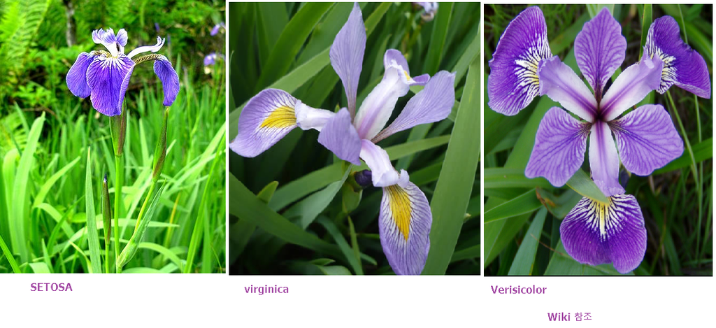

```python
from IPython.display import Image

# 주피터 노트북에서 이미지 표시
display(Image(filename='img/iris_setosa01.png'))
```

### 용어 이해하기

- **클래스(class)** : 출력될 수 있는 값들. 붓꽃의 종류들, 붓꽃의 종류는 세 클래스 중 하나에 속한다.
  - 모델이 예측할 수 있는 범주형 결과값들의 집합
  - (구글 용어집) One of a set of enumerated target values for a label.
  - 예: 붓꽃 데이터셋에서는 세 가지 품종(setosa, versicolor, virginica)이 클래스에 해당
- **레이블(label)** :
  - 개별 데이터 포인트에 할당된 실제 클래스 값.
  - 데이터 포인트 하나(붓꽃 하나)에 대한 기대 출력. **특정 데이터 포인트에 대한 출력**
  - (구글 용어집) 지도학습에서 예에 대한 답변 또는 결과 부분